# A3: SPL Library Checkouts

### Summary Information

To begin with, I wanted to find the months with the most and least checked out Shakespeare items from 2005 to 2023. The month with the most checkouts was in April 2016 with 347 checkouts, while the month with the least checkouts was in August 2005 with 36 checkouts. Its possible that the low number in 2005 may not be indicative of the actual number of checkouts, but instead indicative of a lower number of checkouts having been recorded at that time, as this database was only created in 2017, and relied on older data for previous years. The next information I wanted to find was the most checked out medium- my guess was that physical books would beat out any other media by a huge margin, considering how often Shakespeare’s plays are used in schools, which turned out to be correct: physical books were checked out 15710 times out of the 34113 total checkouts. Continuing this thread, I wanted to find out the most checked out physical book, which ended up being Hamlet, with 1089 total checkouts.

### The Dataset

The Data is collected and published by Seattle Public Library through the Seattle Open Data Portal, who, according to their website, make government data available for the following stated reasons:

> Improve public understanding of City operations and other information concerning their communities. Generate economic opportunity for individuals and companies that benefit from the knowledge created by Open Data. Empower City employees to be more effective, better coordinated internally, and able to identify opportunities to better serve the public Encourage the development of innovative technology solutions that improve quality of life.

The date from 2005 to 2017 was collected as part of an art exhibit by George Legrady that displayed checkout statistics on screen around the downtown location of SPL. After that, data was collected directly by SPL. The checkout data itself is shown anonymously, an ethical way of collecting what could be very sensitive personal data. However, its important to consider who is represented in this data: while the library offers cards to anyone who has any form of id, including shelter id cards and regardless of immigration status, the majority of books in the library are in English, which may be a limitation to anyone who cannot read English well. It also lacks data around purchased books, which could skew data around new releases that are being purchased instead of checked out.

### Covid Trends Over Time Chart

For the first trends over time chart, I wanted to take some information I already knew and see how it was reflected in the data. I know that Romeo and Juliet, Macbeth, and Hamlet are the three Shakespeare plays most used in English classes, and that along with that (possibly because of it), they are the most well known of Shakespeares works. I wanted to zoom into a few specific years, so I chose to compare the Covid trends of these three books. We see a lot of variance month to month, but overall the checkouts for all three books stays fairly steady each year, except for one strange (and extreme) jump taken by Hamlet and Macbeth at the end of 2021. That was still in the middle of the pandemic, so I have no idea why there would be a spike of checkouts there. Macbeths jump in checkouts could correspond to the release of a Macbeth movie in September 2021, but that wouldn’t explain the near identical jump in Hamlet checkouts.

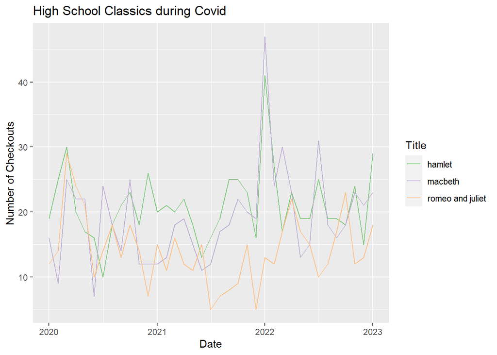

### Genre Trends Over Time Chart

For the second trends over time chart, I was interested in looking at genre. Shakespeares plays can be easily sorted into three categories, comedy, tragedy, and history. I added an ‘other’ category for poems, compilations, and other miscellaneous values. Since I had looked at only a few years, I also wanted to look at the entire timeline this time, from 2005 to 2023. While the monthly variance makes the graph somewhat difficult to read at this timescale, we can see clearly that tragedies starts fairly unpopularly in 2005, but rise to most checked out in 2012 beaten only occasionally by comedies. Histories, a section which comprises of 11 books, stays firmly in the position of least checked out over the whole timeline.

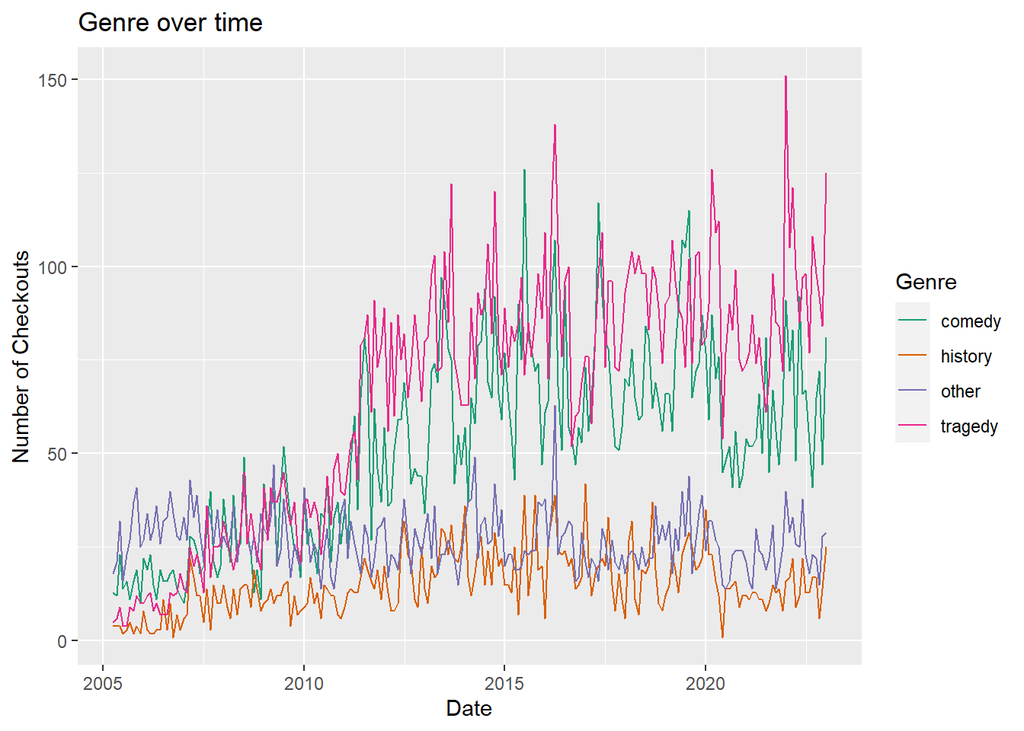

### Comedy and Tragedy Checkout Chart

For the last chart, since we knew from the second chart that comedies and tragedies are the most popular Shakespeare plays by a significant margin, I wanted to compare the checkout numbers for each book. As previously seen, Hamlet is the most checked out, followed closely by Macbeth, and then slightly less closely by Romeo and Juliet. Theres a drop, and then Midsummer Night’s Dream, followed by another drop and then Othello, King Lear, and The Tempest. In a very solid last place, with under 100 checkouts, is Titus Andronicus.

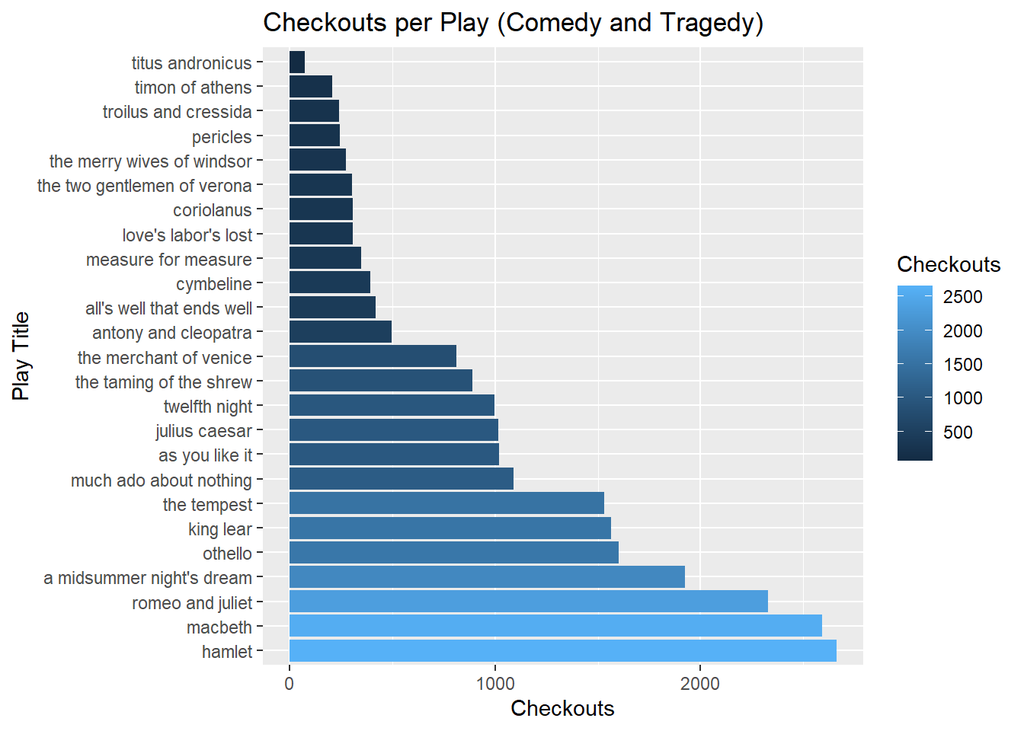